# Лабораторная работа №9

Управление SELinux

Тукаев Тимур

Российский университет дружбы народов, Москва, Россия

16 октября 2025

# Цель работы

## Основная цель

Получить навыки работы с контекстом безопасности и политиками SELinux.  
Освоить принципы конфигурирования, изменения режима работы и восстановления контекстов безопасности.

# Ход выполнения работы

## Проверка состояния SELinux

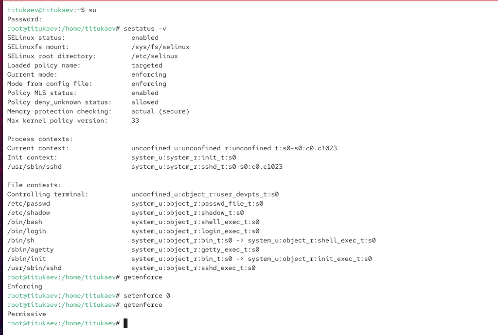

Проверка состояния SELinux

Команда `sestatus -v` показала, что система работает в режиме Enforcing.

## Изменение режима работы SELinux

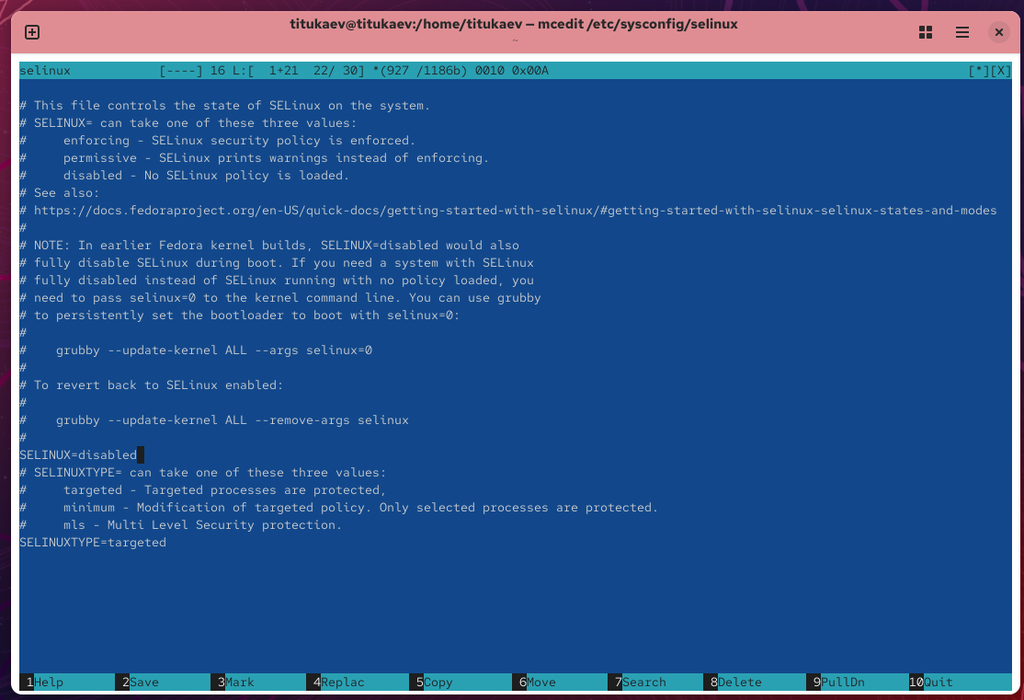

Изменение режима работы SELinux

Режим переведён в Permissive с помощью `setenforce 0`, затем в Disabled через изменение файла конфигурации.

## Проверка после перезагрузки

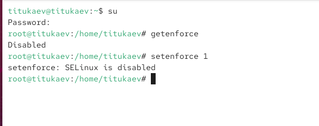

Проверка отключённого состояния SELinux

SELinux отключён. Попытка включить без перезагрузки невозможна.

## Повторное включение SELinux

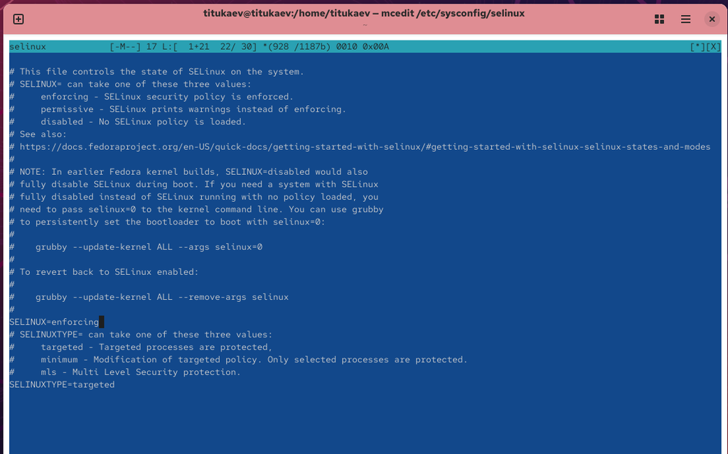

Повторное включение SELinux

Файл `/etc/sysconfig/selinux` изменён на `SELINUX=enforcing`.  
После перезагрузки выполнено relabeling файловой системы.

## Завершение relabeling

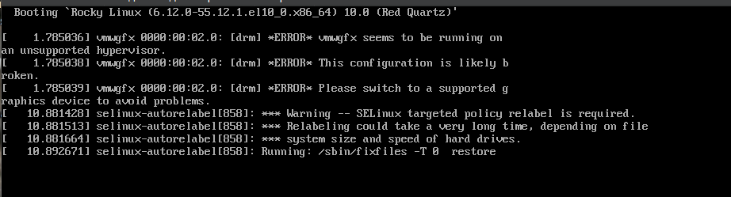

Сообщение о восстановлении меток безопасности

Система автоматически пересоздала метки контекста безопасности.  
SELinux работает в режиме Enforcing.

## Восстановление контекста безопасности

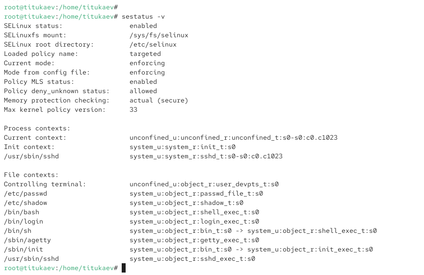

## Настройка контекста для веб-сервера

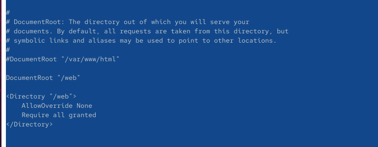

Редактирование httpd.conf и настройка каталога /web

Создан каталог `/web`, добавлен файл `index.html`.  
В конфигурации Apache изменён путь `DocumentRoot`.

## Применение нового контекста SELinux

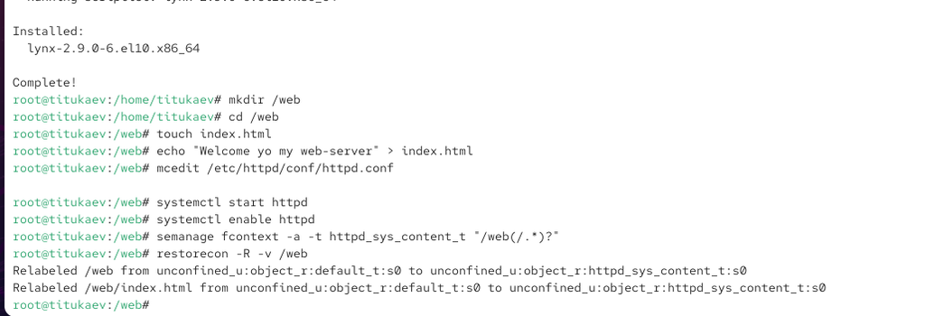

Применение контекста безопасности к /web

К каталогу `/web` применён контекст `httpd_sys_content_t` и выполнено `restorecon -R -v /web`.

## Проверка доступа к веб-странице

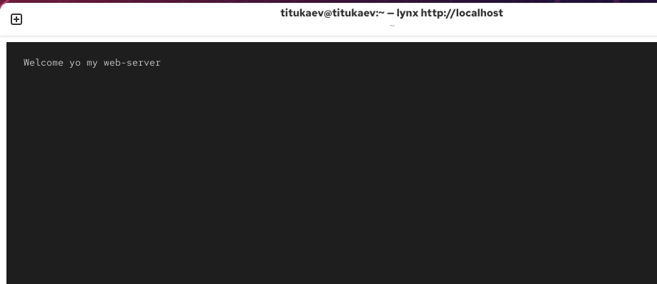

Проверка работы веб-сервера

После применения контекста страница доступна по адресу `http://localhost`.

## Работа с переключателями SELinux

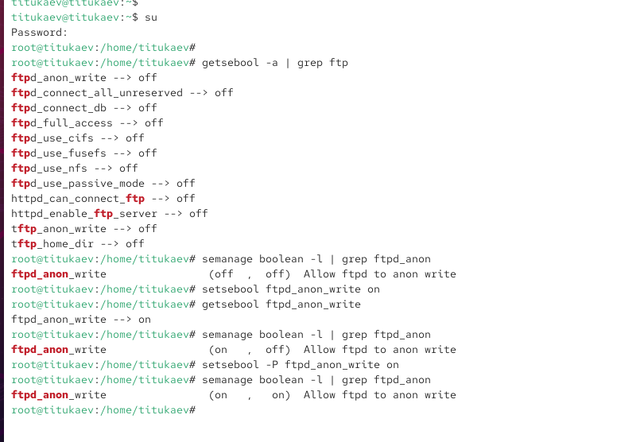

Настройка переключателя ftpd_anon_write

Просмотр, временное и постоянное включение переключателя `ftpd_anon_write` для FTP-службы.  
Параметр активирован (on).

# Итоги работы

## Вывод

Изучены режимы работы SELinux и практические методы их изменения.  
Освоены приёмы назначения и восстановления контекстов безопасности, настройки веб-сервера и управления переключателями SELinux.  
Полученные навыки обеспечивают эффективную настройку и защиту системы Linux.